# Coculture analysis

```r
ma_otu_concom_vi <- prune_taxa("OTU33", ma_otu_concom)
```

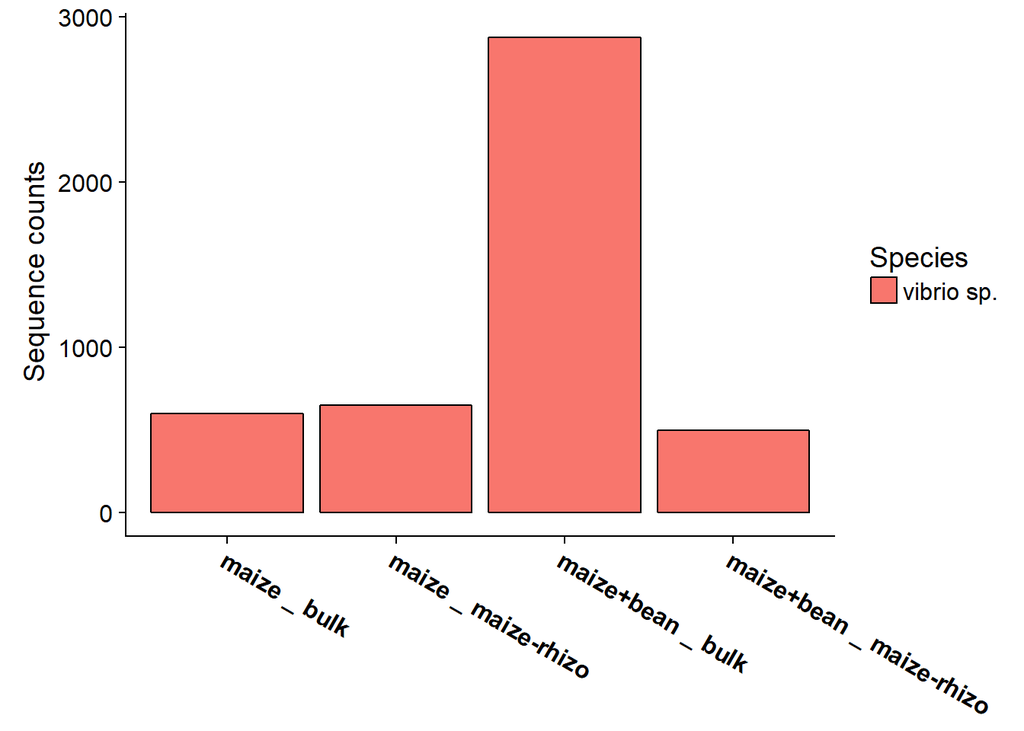

```r
ma_otu_concom_vi %>%
  plot_bar(fill = "Species",
         x = "concom")+
  theme(axis.text.x = element_text(angle = 330, size = 12, face = "bold"),
        axis.title.x = element_blank())+
  ylab(label = " Sequence counts")
```

So here we can see that results observed from the *Vibrionales* order to the *Vibrio sp.* specie are due to the OTU33.

```r
be_otu_concom_pa1 <- prune_taxa("OTU531", be_otu_concom)
```

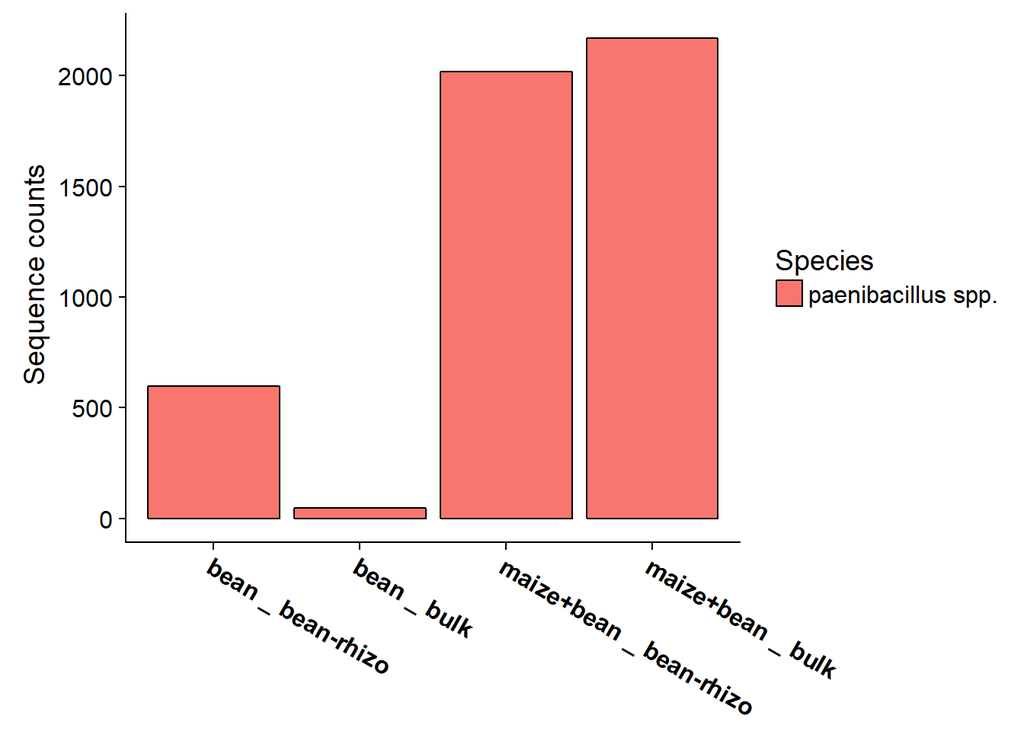

```r
be_otu_concom_pa1 %>%
  plot_bar(fill = "Species",
         x = "concom")+
  theme(axis.text.x = element_text(angle = 330, size = 12, face = "bold"),
        axis.title.x = element_blank())+
  ylab(label = " Sequence counts")
```

```r
ma_otu_concom_pa1 <- prune_taxa("OTU531", ma_otu_concom)
```

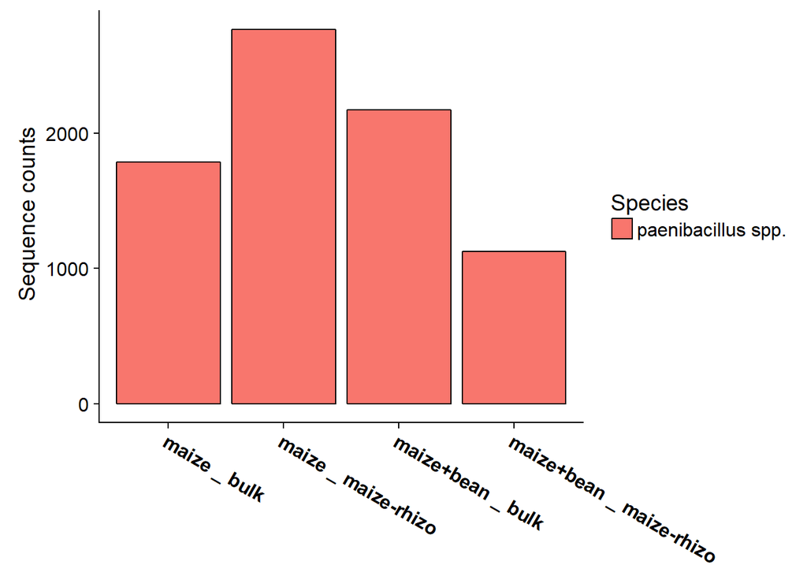

```r
ma_otu_concom_pa1 %>%
  plot_bar(fill = "Species",
         x = "concom")+
  theme(axis.text.x = element_text(angle = 330, size = 12, face = "bold"),
        axis.title.x = element_blank())+
  ylab(label = " Sequence counts")
```

The comparison between the OTU531 abundance within the mono and polyculture bean rhizosphere compartment is not facilitated by this abundance difference observed between mono and polyculture bulk soil. Indeed, there were very few sequences of this OTU within the monoculture bulk soil but there was a lot within the polyculture one. But interestingly, for both bean and maize monoculture, the rhizosphere compartment contained more sequences of this OTU than the bulk soil did, and under polyculture condition, the opposite is observed. Meaning that this OTU abundance is higher within the bulk soil than within the rhizosphere compartments.

```r
be_otu_concom_pa2 <- prune_taxa("OTU147", be_otu_concom)
```

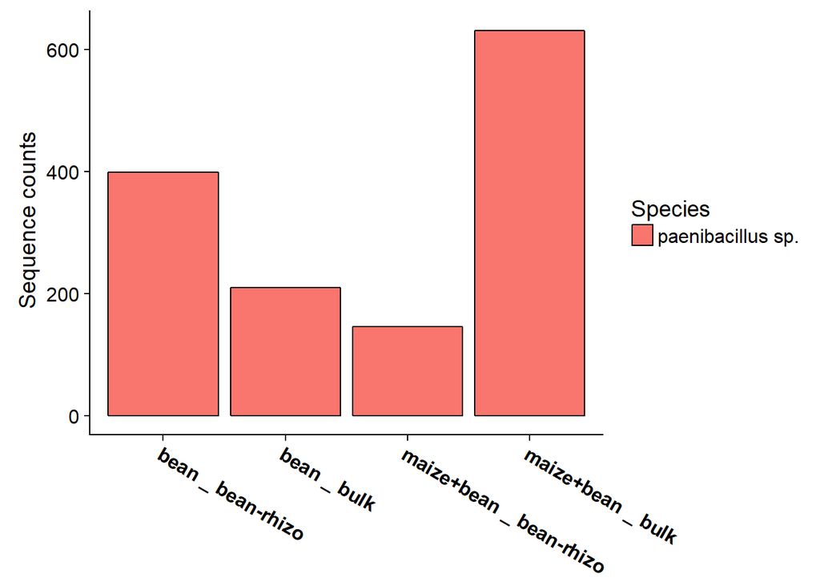

```r
be_otu_concom_pa2 %>%
  plot_bar(fill = "Species",
         x = "concom")+
  theme(axis.text.x = element_text(angle = 330, size = 12, face = "bold"),
        axis.title.x = element_blank())+
  ylab(label = " Sequence counts")
```

```r
ma_otu_concom_pa2 <- prune_taxa("OTU147", ma_otu_concom)
```

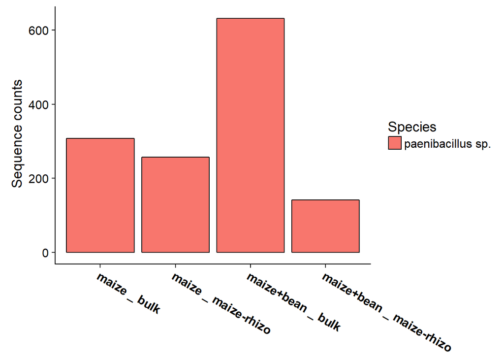

```r
ma_otu_concom_pa2 %>%
  plot_bar(fill = "Species",
         x = "concom")+
  theme(axis.text.x = element_text(angle = 330, size = 12, face = "bold"),
        axis.title.x = element_blank())+
  ylab(label = " Sequence counts")
```

For the bean, kind of the same pattern is observed for the OTU147 (a member of the *Paenibacillus sp.* specie) than for the OTU531. But for the maize, either under mono and polyculture condition, the bulk soil always contained more sequences from the OTU147 than the rhizosphere compartment did.

##### High variance

```r
bean_otus_highVar0.5 =
  filter_taxa(bemobeco,
              function(x) var(x) > 0.5, TRUE)

bean_otus_highVar0.5 <- as.data.frame (bean_otus_highVar0.5@otu_table)

bean_otus_highVar0.5_sup12 <- bean_otus_highVar0.5[rowSums(bean_otus_highVar0.5) > 100,]

bean_otus_highVar0.5_sup12_max5 <- bean_otus_highVar0.5_sup12[rowSums(bean_otus_highVar0.5_sup12 ==0) ==0,]

bmvsbc_hv_otus_s12m5 <- DESeqDataSetFromMatrix(bean_otus_highVar0.5_sup12_max5,
                                 meta_data_bemobeco,
                                 design = ~ culture)
bmvsbc_hv_otus_s12m5 <- DESeq(bmvsbc_hv_otus_s12m5)

bmvsbc_hv_otus_s12m5_res <- results(bmvsbc_hv_otus_s12m5, cooksCutoff = FALSE)

alpha = 0.05

otus_bean_hv_s12m5_sigtab = bmvsbc_hv_otus_s12m5_res[which(bmvsbc_hv_otus_s12m5_res$padj <= alpha), ]

otus_bean_hv_s12m5_sigtab
```

```
## log2 fold change (MLE): culture maize.bean vs bean
## Wald test p-value: culture maize.bean vs bean
## DataFrame with 3 rows and 6 columns
##         baseMean log2FoldChange     lfcSE      stat       pvalue
##        <numeric>      <numeric> <numeric> <numeric>    <numeric>
## OTU147  57.30697      -4.793329 1.2663954 -3.785018 1.536977e-04
## OTU531  85.68787      -3.935381 0.9807135 -4.012773 6.000950e-05
## OTU33  419.77975      -6.450041 1.4353852 -4.493596 7.003040e-06
##               padj
##          <numeric>
## OTU147 0.031712969
## OTU531 0.018572939
## OTU33  0.004334881
```

```
Same result that without variance filtering.
```

## Permanova

### OTU level

```r
physeq.bray <- phyloseq::distance(physeq, "bray")
md <- as.data.frame(cbind(physeq@sam_data[,c("condition", "compartment", "concom", "farmer2")]))
adonis2(physeq.bray ~ condition, data = md)
```

```
## Permutation test for adonis under reduced model
## Terms added sequentially (first to last)
## Permutation: free
## Number of permutations: 999
##
## adonis2(formula = physeq.bray ~ condition, data = md)
##           Df SumOfSqs      F Pr(>F)
## condition  2   0.3112 1.0547  0.369
## Residual  36   5.3119
```

```r
adonis2(physeq.bray ~ compartment, data = md)
```

```
## Permutation test for adonis under reduced model
## Terms added sequentially (first to last)
## Permutation: free
## Number of permutations: 999
##
## adonis2(formula = physeq.bray ~ compartment, data = md)
##             Df SumOfSqs      F Pr(>F)
## compartment  2   0.5263 1.8587  0.007 **
## Residual    36   5.0968
## ---
## Signif. codes:  0 '***' 0.001 '**' 0.01 '*' 0.05 '.' 0.1 ' ' 1
```

```r
adonis2(physeq.bray ~ concom, data = md)
```

```
## Permutation test for adonis under reduced model
## Terms added sequentially (first to last)
## Permutation: free
## Number of permutations: 999
##
## adonis2(formula = physeq.bray ~ concom, data = md)
##          Df SumOfSqs      F Pr(>F)
## concom    6   0.8812 0.9911  0.491
## Residual 32   4.7419
```

```r
adonis2(physeq.bray ~ farmer2, data = md)
```

```
## Permutation test for adonis under reduced model
## Terms added sequentially (first to last)
## Permutation: free
## Number of permutations: 999
##
## adonis2(formula = physeq.bray ~ farmer2, data = md)
##          Df SumOfSqs     F Pr(>F)
## farmer2   7   2.4450 3.407  0.001 ***
## Residual 31   3.1781
## ---
## Signif. codes:  0 '***' 0.001 '**' 0.01 '*' 0.05 '.' 0.1 ' ' 1
```

```r
physeqwb <- subset_samples(physeq, compartment != "bulk")
physeqwb.bray <- phyloseq::distance(physeqwb, "bray")
mdwb <- as.data.frame(cbind(physeqwb@sam_data[,c("condition", "compartment", "concom", "farmer2")]))
adonis2(physeqwb.bray ~ condition, data = mdwb)
```

```
## Permutation test for adonis under reduced model
## Terms added sequentially (first to last)
## Permutation: free
## Number of permutations: 999
##
## adonis2(formula = physeqwb.bray ~ condition, data = mdwb)
##           Df SumOfSqs      F Pr(>F)
## condition  2  0.27103 0.9726  0.475
## Residual  20  2.78677
```

```r
adonis2(physeqwb.bray ~ compartment, data = mdwb)
```

```
## Permutation test for adonis under reduced model
## Terms added sequentially (first to last)
## Permutation: free
## Number of permutations: 999
##
## adonis2(formula = physeqwb.bray ~ compartment, data = mdwb)
##             Df SumOfSqs      F Pr(>F)
## compartment  1  0.20317 1.4947  0.077 .
## Residual    21  2.85462
## ---
## Signif. codes:  0 '***' 0.001 '**' 0.01 '*' 0.05 '.' 0.1 ' ' 1
```

```r
adonis2(physeqwb.bray ~ concom, data = mdwb)
```

```
## Permutation test for adonis under reduced model
## Terms added sequentially (first to last)
## Permutation: free
## Number of permutations: 999
##
## adonis2(formula = physeqwb.bray ~ concom, data = mdwb)
##          Df SumOfSqs      F Pr(>F)
## concom    3  0.39332 0.9349   0.59
## Residual 19  2.66448
```

```r
adonis2(physeqwb.bray ~ farmer2, data = mdwb)
```

```
## Permutation test for adonis under reduced model
## Terms added sequentially (first to last)
## Permutation: free
## Number of permutations: 999
##
## adonis2(formula = physeqwb.bray ~ farmer2, data = mdwb)
##          Df SumOfSqs      F Pr(>F)
## farmer2   7   1.6092 2.3803  0.001 ***
## Residual 15   1.4486
## ---
## Signif. codes:  0 '***' 0.001 '**' 0.01 '*' 0.05 '.' 0.1 ' ' 1
```

#### bean mono vs bean co

```r
bemobeco.bray <- phyloseq::distance(bemobeco, "bray")
bean_otus_md <- as.data.frame(cbind(bemobeco@sam_data[,c("condition", "farmer2")]))
bean_otus_md$condition <- as.factor(bean_otus_md$condition)
adonis2(bemobeco.bray ~ condition, data = bean_otus_md)
```

```
## Permutation test for adonis under reduced model
## Terms added sequentially (first to last)
## Permutation: free
## Number of permutations: 999
##
## adonis2(formula = bemobeco.bray ~ condition, data = bean_otus_md)
##           Df SumOfSqs      F Pr(>F)
## condition  1  0.08462 0.6018  0.937
## Residual   6  0.84368
```

```r
adonis2(bemobeco.bray ~ farmer2, data = bean_otus_md)
```

```
## Permutation test for adonis under reduced model
## Terms added sequentially (first to last)
## Permutation: free
## Number of permutations: 999
##
## adonis2(formula = bemobeco.bray ~ farmer2, data = bean_otus_md)
##          Df SumOfSqs      F Pr(>F)
## farmer2   3  0.53608 1.8224  0.028 *
## Residual  4  0.39222
## ---
## Signif. codes:  0 '***' 0.001 '**' 0.01 '*' 0.05 '.' 0.1 ' ' 1
```

#### maize mono vs maize co

```r
mamomaco.bray <- phyloseq::distance(mamomaco, "bray")
maize_otus_md <- as.data.frame(cbind(mamomaco@sam_data[,c("condition","farmer2")]))
maize_otus_md$condition <- as.factor(maize_otus_md$condition)
adonis2(mamomaco.bray ~ condition, data = maize_otus_md)
```

```
## Permutation test for adonis under reduced model
## Terms added sequentially (first to last)
## Permutation: free
## Number of permutations: 999
##
## adonis2(formula = mamomaco.bray ~ condition, data = maize_otus_md)
##           Df SumOfSqs      F Pr(>F)
## condition  1  0.08687 0.5818  0.925
## Residual   8  1.19441
```

```r
adonis2(mamomaco.bray ~ farmer2, data = maize_otus_md)
```

```
## Permutation test for adonis under reduced model
## Terms added sequentially (first to last)
## Permutation: free
## Number of permutations: 999
##
## adonis2(formula = mamomaco.bray ~ farmer2, data = maize_otus_md)
##          Df SumOfSqs     F Pr(>F)
## farmer2   5  0.94197 2.221  0.002 **
## Residual  4  0.33930
## ---
## Signif. codes:  0 '***' 0.001 '**' 0.01 '*' 0.05 '.' 0.1 ' ' 1
```

### Specie level

```r
physeq_sps.bray <- phyloseq::distance(physeq_sps, "bray")
md_sps <- as.data.frame(cbind(physeq_sps@sam_data[,c("condition", "compartment", "concom", "farmer2")]))
adonis2(physeq_sps.bray ~ condition, data = md_sps)
```

```
## Permutation test for adonis under reduced model
## Terms added sequentially (first to last)
## Permutation: free
## Number of permutations: 999
##
## adonis2(formula = physeq_sps.bray ~ condition, data = md_sps)
##           Df SumOfSqs      F Pr(>F)
## condition  2   0.2223 0.9945  0.446
## Residual  36   4.0240
```

```r
adonis2(physeq_sps.bray ~ compartment, data = md_sps)
```

```
## Permutation test for adonis under reduced model
## Terms added sequentially (first to last)
## Permutation: free
## Number of permutations: 999
##
## adonis2(formula = physeq_sps.bray ~ compartment, data = md_sps)
##             Df SumOfSqs      F Pr(>F)
## compartment  2   0.4357 2.0581  0.001 ***
## Residual    36   3.8106
## ---
## Signif. codes:  0 '***' 0.001 '**' 0.01 '*' 0.05 '.' 0.1 ' ' 1
```

```r
adonis2(physeq_sps.bray ~ concom, data = md_sps)
```

```
## Permutation test for adonis under reduced model
## Terms added sequentially (first to last)
## Permutation: free
## Number of permutations: 999
##
## adonis2(formula = physeq_sps.bray ~ concom, data = md_sps)
##          Df SumOfSqs     F Pr(>F)
## concom    6   0.6778 1.013  0.423
## Residual 32   3.5686
```

```r
adonis2(physeq_sps.bray ~ farmer2, data = md_sps)
```

```
## Permutation test for adonis under reduced model
## Terms added sequentially (first to last)
## Permutation: free
## Number of permutations: 999
##
## adonis2(formula = physeq_sps.bray ~ farmer2, data = md_sps)
##          Df SumOfSqs     F Pr(>F)
## farmer2   7   1.7620 3.141  0.001 ***
## Residual 31   2.4843
## ---
## Signif. codes:  0 '***' 0.001 '**' 0.01 '*' 0.05 '.' 0.1 ' ' 1
```

```r
physeqwb_sps <- subset_samples(physeq_sps, compartment != "bulk")
physeqwb_sps.bray <- phyloseq::distance(physeqwb_sps, "bray")
mdwb_sps <- as.data.frame(cbind(physeqwb_sps@sam_data[,c("condition", "compartment", "concom", "farmer2")]))
adonis2(physeqwb_sps.bray ~ condition, data = mdwb_sps)
```

```
## Permutation test for adonis under reduced model
## Terms added sequentially (first to last)
## Permutation: free
## Number of permutations: 999
##
## adonis2(formula = physeqwb_sps.bray ~ condition, data = mdwb_sps)
##           Df SumOfSqs      F Pr(>F)
## condition  2  0.20126 0.9759  0.485
## Residual  20  2.06233
```

```r
adonis2(physeqwb_sps.bray ~ compartment, data = mdwb_sps)
```

```
## Permutation test for adonis under reduced model
## Terms added sequentially (first to last)
## Permutation: free
## Number of permutations: 999
##
## adonis2(formula = physeqwb_sps.bray ~ compartment, data = mdwb_sps)
##             Df SumOfSqs     F Pr(>F)
## compartment  1  0.17246 1.732  0.057 .
## Residual    21  2.09112
## ---
## Signif. codes:  0 '***' 0.001 '**' 0.01 '*' 0.05 '.' 0.1 ' ' 1
```

```r
adonis2(physeqwb_sps.bray ~ concom, data = mdwb_sps)
```

```
## Permutation test for adonis under reduced model
## Terms added sequentially (first to last)
## Permutation: free
## Number of permutations: 999
##
## adonis2(formula = physeqwb_sps.bray ~ concom, data = mdwb_sps)
##          Df SumOfSqs      F Pr(>F)
## concom    3  0.29967 0.9664  0.506
## Residual 19  1.96392
```

```r
adonis2(physeqwb_sps.bray ~ farmer2, data = mdwb_sps)
```

```
## Permutation test for adonis under reduced model
## Terms added sequentially (first to last)
## Permutation: free
## Number of permutations: 999
##
## adonis2(formula = physeqwb_sps.bray ~ farmer2, data = mdwb_sps)
##          Df SumOfSqs     F Pr(>F)
## farmer2   7   1.1407 2.177  0.001 ***
## Residual 15   1.1228
## ---
## Signif. codes:  0 '***' 0.001 '**' 0.01 '*' 0.05 '.' 0.1 ' ' 1
```

#### bean mono vs bean co

```r
bemobeco_sps.bray <- phyloseq::distance(bemobeco_sps, "bray")
bean_sps_md <- as.data.frame(cbind(bemobeco_sps@sam_data[,c("condition", "farmer2")]))
bean_sps_md$condition <- as.factor(bean_sps_md$condition)
adonis2(bemobeco_sps.bray ~ condition, data = bean_sps_md)
```

```
## Permutation test for adonis under reduced model
## Terms added sequentially (first to last)
## Permutation: free
## Number of permutations: 999
##
## adonis2(formula = bemobeco_sps.bray ~ condition, data = bean_sps_md)
##           Df SumOfSqs      F Pr(>F)
## condition  1   0.0545 0.4986      1
## Residual   6   0.6558
```

```r
adonis2(bemobeco_sps.bray ~ farmer2, data = bean_sps_md)
```

```
## Permutation test for adonis under reduced model
## Terms added sequentially (first to last)
## Permutation: free
## Number of permutations: 999
##
## adonis2(formula = bemobeco_sps.bray ~ farmer2, data = bean_sps_md)
##          Df SumOfSqs     F Pr(>F)
## farmer2   3  0.40659 1.785  0.018 *
## Residual  4  0.30370
## ---
## Signif. codes:  0 '***' 0.001 '**' 0.01 '*' 0.05 '.' 0.1 ' ' 1
```

#### maize mono vs maize co

```r
mamomaco_sps.bray <- phyloseq::distance(mamomaco_sps, "bray")
maize_sps_md <- as.data.frame(cbind(mamomaco_sps@sam_data[,c("condition","farmer2")]))
adonis2(mamomaco_sps.bray ~ condition, data = maize_sps_md)
```

```
## Permutation test for adonis under reduced model
## Terms added sequentially (first to last)
## Permutation: free
## Number of permutations: 999
##
## adonis2(formula = mamomaco_sps.bray ~ condition, data = maize_sps_md)
##           Df SumOfSqs      F Pr(>F)
## condition  1  0.06856 0.6412  0.818
## Residual   8  0.85537
```

```r
adonis2(mamomaco_sps.bray ~ farmer2, data = maize_sps_md)
```

```
## Permutation test for adonis under reduced model
## Terms added sequentially (first to last)
## Permutation: free
## Number of permutations: 999
##
## adonis2(formula = mamomaco_sps.bray ~ farmer2, data = maize_sps_md)
##          Df SumOfSqs      F Pr(>F)
## farmer2   5  0.66881 2.0972  0.004 **
## Residual  4  0.25512
## ---
## Signif. codes:  0 '***' 0.001 '**' 0.01 '*' 0.05 '.' 0.1 ' ' 1
```

### Genus level

```r
physeq_gns.bray <- phyloseq::distance(physeq_gns, "bray")
md_gns <- as.data.frame(cbind(physeq_gns@sam_data[,c("condition", "compartment", "concom", "farmer2")]))
adonis2(physeq_gns.bray ~ condition, data = md_gns)
```

```
## Permutation test for adonis under reduced model
## Terms added sequentially (first to last)
## Permutation: free
## Number of permutations: 999
##
## adonis2(formula = physeq_gns.bray ~ condition, data = md_gns)
##           Df SumOfSqs     F Pr(>F)
## condition  2  0.15891 0.969  0.514
## Residual  36  2.95197
```

```r
adonis2(physeq_gns.bray ~ compartment, data = md_gns)
```

```
## Permutation test for adonis under reduced model
## Terms added sequentially (first to last)
## Permutation: free
## Number of permutations: 999
##
## adonis2(formula = physeq_gns.bray ~ compartment, data = md_gns)
##             Df SumOfSqs      F Pr(>F)
## compartment  2  0.26832 1.6991  0.032 *
## Residual    36  2.84256
## ---
## Signif. codes:  0 '***' 0.001 '**' 0.01 '*' 0.05 '.' 0.1 ' ' 1
```

```r
adonis2(physeq_gns.bray ~ concom, data = md_gns)
```

```
## Permutation test for adonis under reduced model
## Terms added sequentially (first to last)
## Permutation: free
## Number of permutations: 999
##
## adonis2(formula = physeq_gns.bray ~ concom, data = md_gns)
##          Df SumOfSqs      F Pr(>F)
## concom    6  0.45116 0.9047  0.696
## Residual 32  2.65972
```

```r
adonis2(physeq_gns.bray ~ farmer2, data = md_gns)
```

```
## Permutation test for adonis under reduced model
## Terms added sequentially (first to last)
## Permutation: free
## Number of permutations: 999
##
## adonis2(formula = physeq_gns.bray ~ farmer2, data = md_gns)
##          Df SumOfSqs      F Pr(>F)
## farmer2   7   1.3709 3.4894  0.001 ***
## Residual 31   1.7399
## ---
## Signif. codes:  0 '***' 0.001 '**' 0.01 '*' 0.05 '.' 0.1 ' ' 1
```

```r
physeqwb_gns <- subset_samples(physeq_gns, compartment != "bulk")
physeqwb_gns.bray <- phyloseq::distance(physeqwb_gns, "bray")
mdwb_gns <- as.data.frame(cbind(physeqwb_gns@sam_data[,c("condition", "compartment", "concom", "farmer2")]))
adonis2(physeqwb_gns.bray ~ condition, data = mdwb_gns)
```

```
## Permutation test for adonis under reduced model
## Terms added sequentially (first to last)
## Permutation: free
## Number of permutations: 999
##
## adonis2(formula = physeqwb_gns.bray ~ condition, data = mdwb_gns)
##           Df SumOfSqs      F Pr(>F)
## condition  2  0.13075 0.8448  0.668
## Residual  20  1.54761
```

```r
adonis2(physeqwb_gns.bray ~ compartment, data = mdwb_gns)
```

```
## Permutation test for adonis under reduced model
## Terms added sequentially (first to last)
## Permutation: free
## Number of permutations: 999
##
## adonis2(formula = physeqwb_gns.bray ~ compartment, data = mdwb_gns)
##             Df SumOfSqs      F Pr(>F)
## compartment  1  0.12585 1.7023  0.069 .
## Residual    21  1.55251
## ---
## Signif. codes:  0 '***' 0.001 '**' 0.01 '*' 0.05 '.' 0.1 ' ' 1
```

```r
adonis2(physeqwb_gns.bray ~ concom, data = mdwb_gns)
```

```
## Permutation test for adonis under reduced model
## Terms added sequentially (first to last)
## Permutation: free
## Number of permutations: 999
##
## adonis2(formula = physeqwb_gns.bray ~ concom, data = mdwb_gns)
##          Df SumOfSqs      F Pr(>F)
## concom    3  0.21416 0.9263    0.6
## Residual 19  1.46420
```

```r
adonis2(physeqwb_gns.bray ~ farmer2, data = mdwb_gns)
```

```
## Permutation test for adonis under reduced model
## Terms added sequentially (first to last)
## Permutation: free
## Number of permutations: 999
##
## adonis2(formula = physeqwb_gns.bray ~ farmer2, data = mdwb_gns)
##          Df SumOfSqs      F Pr(>F)
## farmer2   7  0.87862 2.3542  0.001 ***
## Residual 15  0.79974
## ---
## Signif. codes:  0 '***' 0.001 '**' 0.01 '*' 0.05 '.' 0.1 ' ' 1
```

#### bean mono vs bean co

```r
bemobeco_gns.bray <- phyloseq::distance(bemobeco_gns, "bray")
bean_gns_md <- as.data.frame(cbind(bemobeco_gns@sam_data[,c("condition", "farmer2")]))
bean_gns_md$condition <- as.factor(bean_gns_md$condition)
adonis2(bemobeco_gns.bray ~ condition, data = bean_gns_md)
```

```
## Permutation test for adonis under reduced model
## Terms added sequentially (first to last)
## Permutation: free
## Number of permutations: 999
##
## adonis2(formula = bemobeco_gns.bray ~ condition, data = bean_gns_md)
##           Df SumOfSqs      F Pr(>F)
## condition  1  0.04114 0.4772  0.942
## Residual   6  0.51721
```

```r
adonis2(bemobeco_gns.bray ~ farmer2, data = bean_gns_md)
```

```
## Permutation test for adonis under reduced model
## Terms added sequentially (first to last)
## Permutation: free
## Number of permutations: 999
##
## adonis2(formula = bemobeco_gns.bray ~ farmer2, data = bean_gns_md)
##          Df SumOfSqs      F Pr(>F)
## farmer2   3  0.31932 1.7813  0.027 *
## Residual  4  0.23903
## ---
## Signif. codes:  0 '***' 0.001 '**' 0.01 '*' 0.05 '.' 0.1 ' ' 1
```

#### maize mono vs maize co

```r
mamomaco_gns.bray <- phyloseq::distance(mamomaco_gns, "bray")
maize_gns_md <- as.data.frame(cbind(mamomaco_gns@sam_data[,c("condition","farmer2")]))
adonis2(mamomaco_gns.bray ~ condition, data = maize_gns_md)
```

```
## Permutation test for adonis under reduced model
## Terms added sequentially (first to last)
## Permutation: free
## Number of permutations: 999
##
## adonis2(formula = mamomaco_gns.bray ~ condition, data = maize_gns_md)
##           Df SumOfSqs      F Pr(>F)
## condition  1  0.04292 0.5638  0.875
## Residual   8  0.60901
```

```r
adonis2(mamomaco_gns.bray ~ farmer2, data = maize_gns_md)
```

```
## Permutation test for adonis under reduced model
## Terms added sequentially (first to last)
## Permutation: free
## Number of permutations: 999
##
## adonis2(formula = mamomaco_gns.bray ~ farmer2, data = maize_gns_md)
##          Df SumOfSqs      F Pr(>F)
## farmer2   5  0.48288 2.2851  0.003 **
## Residual  4  0.16905
## ---
## Signif. codes:  0 '***' 0.001 '**' 0.01 '*' 0.05 '.' 0.1 ' ' 1
```

### family level

```r
physeq_fmy.bray <- phyloseq::distance(physeq_fmy, "bray")
md_fmy <- as.data.frame(cbind(physeq_fmy@sam_data[,c("condition", "compartment", "concom", "farmer2")]))
adonis2(physeq_fmy.bray ~ condition, data = md_fmy)
```

```
## Permutation test for adonis under reduced model
## Terms added sequentially (first to last)
## Permutation: free
## Number of permutations: 999
##
## adonis2(formula = physeq_fmy.bray ~ condition, data = md_fmy)
##           Df SumOfSqs      F Pr(>F)
## condition  2   0.1261 1.0498  0.389
## Residual  36   2.1620
```

```r
adonis2(physeq_fmy.bray ~ compartment, data = md_fmy)
```

```
## Permutation test for adonis under reduced model
## Terms added sequentially (first to last)
## Permutation: free
## Number of permutations: 999
##
## adonis2(formula = physeq_fmy.bray ~ compartment, data = md_fmy)
##             Df SumOfSqs      F Pr(>F)
## compartment  2  0.19715 1.6972  0.039 *
## Residual    36  2.09094
## ---
## Signif. codes:  0 '***' 0.001 '**' 0.01 '*' 0.05 '.' 0.1 ' ' 1
```

```r
adonis2(physeq_fmy.bray ~ concom, data = md_fmy)
```

```
## Permutation test for adonis under reduced model
## Terms added sequentially (first to last)
## Permutation: free
## Number of permutations: 999
##
## adonis2(formula = physeq_fmy.bray ~ concom, data = md_fmy)
##          Df SumOfSqs     F Pr(>F)
## concom    6  0.34068 0.933  0.589
## Residual 32  1.94741
```

```r
adonis2(physeq_fmy.bray ~ farmer2, data = md_fmy)
```

```
## Permutation test for adonis under reduced model
## Terms added sequentially (first to last)
## Permutation: free
## Number of permutations: 999
##
## adonis2(formula = physeq_fmy.bray ~ farmer2, data = md_fmy)
##          Df SumOfSqs     F Pr(>F)
## farmer2   7  0.98508 3.348  0.001 ***
## Residual 31  1.30300
## ---
## Signif. codes:  0 '***' 0.001 '**' 0.01 '*' 0.05 '.' 0.1 ' ' 1
```

```r
physeqwb_fmy <- subset_samples(physeq_fmy, compartment != "bulk")
physeqwb_fmy.bray <- phyloseq::distance(physeqwb_fmy, "bray")
mdwb_fmy <- as.data.frame(cbind(physeqwb_fmy@sam_data[,c("condition", "compartment", "concom", "farmer2")]))
adonis2(physeqwb_fmy.bray ~ condition, data = mdwb_fmy)
```

```
## Permutation test for adonis under reduced model
## Terms added sequentially (first to last)
## Permutation: free
## Number of permutations: 999
##
## adonis2(formula = physeqwb_fmy.bray ~ condition, data = mdwb_fmy)
##           Df SumOfSqs      F Pr(>F)
## condition  2  0.09782 0.8381  0.639
## Residual  20  1.16708
```

```r
adonis2(physeqwb_fmy.bray ~ compartment, data = mdwb_fmy)
```

```
## Permutation test for adonis under reduced model
## Terms added sequentially (first to last)
## Permutation: free
## Number of permutations: 999
##
## adonis2(formula = physeqwb_fmy.bray ~ compartment, data = mdwb_fmy)
##             Df SumOfSqs      F Pr(>F)
## compartment  1  0.08901 1.5896  0.113
## Residual    21  1.17589
```

```r
adonis2(physeqwb_fmy.bray ~ concom, data = mdwb_fmy)
```

```
## Permutation test for adonis under reduced model
## Terms added sequentially (first to last)
## Permutation: free
## Number of permutations: 999
##
## adonis2(formula = physeqwb_fmy.bray ~ concom, data = mdwb_fmy)
##          Df SumOfSqs      F Pr(>F)
## concom    3  0.15882 0.9094  0.584
## Residual 19  1.10607
```

```r
adonis2(physeqwb_fmy.bray ~ farmer2, data = mdwb_fmy)
```

```
## Permutation test for adonis under reduced model
## Terms added sequentially (first to last)
## Permutation: free
## Number of permutations: 999
##
## adonis2(formula = physeqwb_fmy.bray ~ farmer2, data = mdwb_fmy)
##          Df SumOfSqs      F Pr(>F)
## farmer2   7  0.67605 2.4602  0.001 ***
## Residual 15  0.58885
## ---
## Signif. codes:  0 '***' 0.001 '**' 0.01 '*' 0.05 '.' 0.1 ' ' 1
```

#### bean mono vs bean co

```r
bemobeco_fmy.bray <- phyloseq::distance(bemobeco_fmy, "bray")
bean_fmy_md <- as.data.frame(cbind(bemobeco_fmy@sam_data[,c("condition", "farmer2")]))
bean_fmy_md$condition <- as.factor(bean_fmy_md$condition)
adonis2(bemobeco_fmy.bray ~ condition, data = bean_fmy_md)
```

```
## Permutation test for adonis under reduced model
## Terms added sequentially (first to last)
## Permutation: free
## Number of permutations: 999
##
## adonis2(formula = bemobeco_fmy.bray ~ condition, data = bean_fmy_md)
##           Df SumOfSqs      F Pr(>F)
## condition  1  0.04526 0.6445  0.778
## Residual   6  0.42137
```

```r
adonis2(bemobeco_fmy.bray ~ farmer2, data = bean_fmy_md)
```

```
## Permutation test for adonis under reduced model
## Terms added sequentially (first to last)
## Permutation: free
## Number of permutations: 999
##
## adonis2(formula = bemobeco_fmy.bray ~ farmer2, data = bean_fmy_md)
##          Df SumOfSqs      F Pr(>F)
## farmer2   3  0.27088 1.8451  0.017 *
## Residual  4  0.19575
## ---
## Signif. codes:  0 '***' 0.001 '**' 0.01 '*' 0.05 '.' 0.1 ' ' 1
```

#### maize mono vs maize co

```r
mamomaco_fmy.bray <- phyloseq::distance(mamomaco_fmy, "bray")
maize_fmy_md <- as.data.frame(cbind(mamomaco_fmy@sam_data[,c("condition","farmer2")]))
adonis2(mamomaco_fmy.bray ~ condition, data = maize_fmy_md)
```

```
## Permutation test for adonis under reduced model
## Terms added sequentially (first to last)
## Permutation: free
## Number of permutations: 999
##
## adonis2(formula = mamomaco_fmy.bray ~ condition, data = maize_fmy_md)
##           Df SumOfSqs      F Pr(>F)
## condition  1  0.02812 0.5178   0.83
## Residual   8  0.43446
```

```r
adonis2(mamomaco_fmy.bray ~ farmer2, data = maize_fmy_md)
```

```
## Permutation test for adonis under reduced model
## Terms added sequentially (first to last)
## Permutation: free
## Number of permutations: 999
##
## adonis2(formula = mamomaco_fmy.bray ~ farmer2, data = maize_fmy_md)
##          Df SumOfSqs      F Pr(>F)
## farmer2   5  0.34818 2.4348  0.006 **
## Residual  4  0.11440
## ---
## Signif. codes:  0 '***' 0.001 '**' 0.01 '*' 0.05 '.' 0.1 ' ' 1
```

### Order level

```r
physeq_odr.bray <- phyloseq::distance(physeq_odr, "bray")
md_odr <- as.data.frame(cbind(physeq_odr@sam_data[,c("condition", "compartment", "concom", "farmer2")]))
adonis2(physeq_odr.bray ~ condition, data = md_odr)
```

```
## Permutation test for adonis under reduced model
## Terms added sequentially (first to last)
## Permutation: free
## Number of permutations: 999
##
## adonis2(formula = physeq_odr.bray ~ condition, data = md_odr)
##           Df SumOfSqs      F Pr(>F)
## condition  2  0.09125 0.9676  0.474
## Residual  36  1.69752
```

```r
adonis2(physeq_odr.bray ~ compartment, data = md_odr)
```

```
## Permutation test for adonis under reduced model
## Terms added sequentially (first to last)
## Permutation: free
## Number of permutations: 999
##
## adonis2(formula = physeq_odr.bray ~ compartment, data = md_odr)
##             Df SumOfSqs      F Pr(>F)
## compartment  2  0.13232 1.4379  0.134
## Residual    36  1.65645
```

```r
adonis2(physeq_odr.bray ~ concom, data = md_odr)
```

```
## Permutation test for adonis under reduced model
## Terms added sequentially (first to last)
## Permutation: free
## Number of permutations: 999
##
## adonis2(formula = physeq_odr.bray ~ concom, data = md_odr)
##          Df SumOfSqs      F Pr(>F)
## concom    6  0.23915 0.8231  0.751
## Residual 32  1.54962
```

```r
adonis2(physeq_odr.bray ~ farmer2, data = md_odr)
```

```
## Permutation test for adonis under reduced model
## Terms added sequentially (first to last)
## Permutation: free
## Number of permutations: 999
##
## adonis2(formula = physeq_odr.bray ~ farmer2, data = md_odr)
##          Df SumOfSqs      F Pr(>F)
## farmer2   7  0.74832 3.1852  0.001 ***
## Residual 31  1.04045
## ---
## Signif. codes:  0 '***' 0.001 '**' 0.01 '*' 0.05 '.' 0.1 ' ' 1
```

```r
physeqwb_odr <- subset_samples(physeq_odr, compartment != "bulk")
physeqwb_odr.bray <- phyloseq::distance(physeqwb_odr, "bray")
mdwb_odr <- as.data.frame(cbind(physeqwb_odr@sam_data[,c("condition", "compartment", "concom", "farmer2")]))
adonis2(physeqwb_odr.bray ~ condition, data = mdwb_odr)
```

```
## Permutation test for adonis under reduced model
## Terms added sequentially (first to last)
## Permutation: free
## Number of permutations: 999
##
## adonis2(formula = physeqwb_odr.bray ~ condition, data = mdwb_odr)
##           Df SumOfSqs      F Pr(>F)
## condition  2  0.07137 0.7595  0.713
## Residual  20  0.93971
```

```r
adonis2(physeqwb_odr.bray ~ compartment, data = mdwb_odr)
```

```
## Permutation test for adonis under reduced model
## Terms added sequentially (first to last)
## Permutation: free
## Number of permutations: 999
##
## adonis2(formula = physeqwb_odr.bray ~ compartment, data = mdwb_odr)
##             Df SumOfSqs      F Pr(>F)
## compartment  1  0.06611 1.4691  0.175
## Residual    21  0.94497
```

```r
adonis2(physeqwb_odr.bray ~ concom, data = mdwb_odr)
```

```
## Permutation test for adonis under reduced model
## Terms added sequentially (first to last)
## Permutation: free
## Number of permutations: 999
##
## adonis2(formula = physeqwb_odr.bray ~ concom, data = mdwb_odr)
##          Df SumOfSqs      F Pr(>F)
## concom    3  0.11958 0.8495  0.648
## Residual 19  0.89150
```

```r
adonis2(physeqwb_odr.bray ~ farmer2, data = mdwb_odr)
```

```
## Permutation test for adonis under reduced model
## Terms added sequentially (first to last)
## Permutation: free
## Number of permutations: 999
##
## adonis2(formula = physeqwb_odr.bray ~ farmer2, data = mdwb_odr)
##          Df SumOfSqs      F Pr(>F)
## farmer2   7  0.51952 2.2648  0.008 **
## Residual 15  0.49155
## ---
## Signif. codes:  0 '***' 0.001 '**' 0.01 '*' 0.05 '.' 0.1 ' ' 1
```

#### bean mono vs bean co

```r
bemobeco_fmy.bray <- phyloseq::distance(bemobeco_fmy, "bray")
bean_fmy_md <- as.data.frame(cbind(bemobeco_fmy@sam_data[,c("condition", "farmer2")]))
bean_fmy_md$condition <- as.factor(bean_fmy_md$condition)
adonis2(bemobeco_fmy.bray ~ condition, data = bean_fmy_md)
```

```
## Permutation test for adonis under reduced model
## Terms added sequentially (first to last)
## Permutation: free
## Number of permutations: 999
##
## adonis2(formula = bemobeco_fmy.bray ~ condition, data = bean_fmy_md)
##           Df SumOfSqs      F Pr(>F)
## condition  1  0.04526 0.6445  0.778
## Residual   6  0.42137
```

```r
adonis2(bemobeco_fmy.bray ~ farmer2, data = bean_fmy_md)
```

```
## Permutation test for adonis under reduced model
## Terms added sequentially (first to last)
## Permutation: free
## Number of permutations: 999
##
## adonis2(formula = bemobeco_fmy.bray ~ farmer2, data = bean_fmy_md)
##          Df SumOfSqs      F Pr(>F)
## farmer2   3  0.27088 1.8451  0.021 *
## Residual  4  0.19575
## ---
## Signif. codes:  0 '***' 0.001 '**' 0.01 '*' 0.05 '.' 0.1 ' ' 1
```

#### maize mono vs maize co

```r
mamomaco_fmy.bray <- phyloseq::distance(mamomaco_fmy, "bray")
maize_fmy_md <- as.data.frame(cbind(mamomaco_fmy@sam_data[,c("condition","farmer2")]))
adonis2(mamomaco_fmy.bray ~ condition, data = maize_fmy_md)
```

```
## Permutation test for adonis under reduced model
## Terms added sequentially (first to last)
## Permutation: free
## Number of permutations: 999
##
## adonis2(formula = mamomaco_fmy.bray ~ condition, data = maize_fmy_md)
##           Df SumOfSqs      F Pr(>F)
## condition  1  0.02812 0.5178  0.845
## Residual   8  0.43446
```

```r
adonis2(mamomaco_fmy.bray ~ farmer2, data = maize_fmy_md)
```

```
## Permutation test for adonis under reduced model
## Terms added sequentially (first to last)
## Permutation: free
## Number of permutations: 999
##
## adonis2(formula = mamomaco_fmy.bray ~ farmer2, data = maize_fmy_md)
##          Df SumOfSqs      F Pr(>F)
## farmer2   5  0.34818 2.4348  0.007 **
## Residual  4  0.11440
## ---
## Signif. codes:  0 '***' 0.001 '**' 0.01 '*' 0.05 '.' 0.1 ' ' 1
```

### Class level

```r
physeq_cls.bray <- phyloseq::distance(physeq_cls, "bray")
md_cls <- as.data.frame(cbind(physeq_cls@sam_data[,c("condition", "compartment", "concom", "farmer2")]))
adonis2(physeq_cls.bray ~ condition, data = md_cls)
```

```
## Permutation test for adonis under reduced model
## Terms added sequentially (first to last)
## Permutation: free
## Number of permutations: 999
##
## adonis2(formula = physeq_cls.bray ~ condition, data = md_cls)
##           Df SumOfSqs      F Pr(>F)
## condition  2  0.05504 0.7536  0.655
## Residual  36  1.31469
```

```r
adonis2(physeq_cls.bray ~ compartment, data = md_cls)
```

```
## Permutation test for adonis under reduced model
## Terms added sequentially (first to last)
## Permutation: free
## Number of permutations: 999
##
## adonis2(formula = physeq_cls.bray ~ compartment, data = md_cls)
##             Df SumOfSqs      F Pr(>F)
## compartment  2  0.03303 0.4447   0.92
## Residual    36  1.33670
```

```r
adonis2(physeq_cls.bray ~ concom, data = md_cls)
```

```
## Permutation test for adonis under reduced model
## Terms added sequentially (first to last)
## Permutation: free
## Number of permutations: 999
##
## adonis2(formula = physeq_cls.bray ~ concom, data = md_cls)
##          Df SumOfSqs      F Pr(>F)
## concom    6   0.1148 0.4879  0.983
## Residual 32   1.2549
```

```r
adonis2(physeq_cls.bray ~ farmer2, data = md_cls)
```

```
## Permutation test for adonis under reduced model
## Terms added sequentially (first to last)
## Permutation: free
## Number of permutations: 999
##
## adonis2(formula = physeq_cls.bray ~ farmer2, data = md_cls)
##          Df SumOfSqs      F Pr(>F)
## farmer2   7  0.70509 4.6981  0.001 ***
## Residual 31  0.66464
## ---
## Signif. codes:  0 '***' 0.001 '**' 0.01 '*' 0.05 '.' 0.1 ' ' 1
```

```r
physeqwb_cls <- subset_samples(physeq_cls, compartment != "bulk")
physeqwb_cls.bray <- phyloseq::distance(physeqwb_cls, "bray")
mdwb_cls <- as.data.frame(cbind(physeqwb_cls@sam_data[,c("condition", "compartment", "concom", "farmer2")]))
adonis2(physeqwb_cls.bray ~ condition, data = mdwb_cls)
```

```
## Permutation test for adonis under reduced model
## Terms added sequentially (first to last)
## Permutation: free
## Number of permutations: 999
##
## adonis2(formula = physeqwb_cls.bray ~ condition, data = mdwb_cls)
##           Df SumOfSqs      F Pr(>F)
## condition  2  0.05353 0.7252  0.705
## Residual  20  0.73803
```

```r
adonis2(physeqwb_cls.bray ~ compartment, data = mdwb_cls)
```

```
## Permutation test for adonis under reduced model
## Terms added sequentially (first to last)
## Permutation: free
## Number of permutations: 999
##
## adonis2(formula = physeqwb_cls.bray ~ compartment, data = mdwb_cls)
##             Df SumOfSqs      F Pr(>F)
## compartment  1  0.03066 0.8463  0.525
## Residual    21  0.76089
```

```r
adonis2(physeqwb_cls.bray ~ concom, data = mdwb_cls)
```

```
## Permutation test for adonis under reduced model
## Terms added sequentially (first to last)
## Permutation: free
## Number of permutations: 999
##
## adonis2(formula = physeqwb_cls.bray ~ concom, data = mdwb_cls)
##          Df SumOfSqs      F Pr(>F)
## concom    3  0.07734 0.6858  0.814
## Residual 19  0.71422
```

```r
adonis2(physeqwb_cls.bray ~ farmer2, data = mdwb_cls)
```

```
## Permutation test for adonis under reduced model
## Terms added sequentially (first to last)
## Permutation: free
## Number of permutations: 999
##
## adonis2(formula = physeqwb_cls.bray ~ farmer2, data = mdwb_cls)
##          Df SumOfSqs     F Pr(>F)
## farmer2   7  0.44467 2.747  0.003 **
## Residual 15  0.34688
## ---
## Signif. codes:  0 '***' 0.001 '**' 0.01 '*' 0.05 '.' 0.1 ' ' 1
```

#### bean mono vs bean co

```r
bemobeco_cls.bray <- phyloseq::distance(bemobeco_cls, "bray")
bean_cls_md <- as.data.frame(cbind(bemobeco_cls@sam_data[,c("condition", "farmer2")]))
bean_cls_md$condition <- as.factor(bean_cls_md$condition)
adonis2(bemobeco_cls.bray ~ condition, data = bean_cls_md)
```

```
## Permutation test for adonis under reduced model
## Terms added sequentially (first to last)
## Permutation: free
## Number of permutations: 999
##
## adonis2(formula = bemobeco_cls.bray ~ condition, data = bean_cls_md)
##           Df SumOfSqs     F Pr(>F)
## condition  1 0.020716 0.403  0.804
## Residual   6 0.308460
```

```r
adonis2(bemobeco_cls.bray ~ farmer2, data = bean_cls_md)
```

```
## Permutation test for adonis under reduced model
## Terms added sequentially (first to last)
## Permutation: free
## Number of permutations: 999
##
## adonis2(formula = bemobeco_cls.bray ~ farmer2, data = bean_cls_md)
##          Df SumOfSqs      F Pr(>F)
## farmer2   3  0.19675 1.9811  0.195
## Residual  4  0.13242
```

#### maize mono vs maize co

```r
mamomaco_cls.bray <- phyloseq::distance(mamomaco_cls, "bray")
maize_cls_md <- as.data.frame(cbind(mamomaco_cls@sam_data[,c("condition","farmer2")]))
adonis2(mamomaco_cls.bray ~ condition, data = maize_cls_md)
```

```
## Permutation test for adonis under reduced model
## Terms added sequentially (first to last)
## Permutation: free
## Number of permutations: 999
##
## adonis2(formula = mamomaco_cls.bray ~ condition, data = maize_cls_md)
##           Df SumOfSqs      F Pr(>F)
## condition  1 0.026521 0.8863  0.497
## Residual   8 0.239398
```

```r
adonis2(mamomaco_cls.bray ~ farmer2, data = maize_cls_md)
```

```
## Permutation test for adonis under reduced model
## Terms added sequentially (first to last)
## Permutation: free
## Number of permutations: 999
##
## adonis2(formula = mamomaco_cls.bray ~ farmer2, data = maize_cls_md)
##          Df SumOfSqs      F Pr(>F)
## farmer2   5 0.201530 2.5039  0.027 *
## Residual  4 0.064389
## ---
## Signif. codes:  0 '***' 0.001 '**' 0.01 '*' 0.05 '.' 0.1 ' ' 1
```

### Phylum level

```r
physeq_plm.bray <- phyloseq::distance(physeq_plm, "bray")
md_plm <- as.data.frame(cbind(physeq_plm@sam_data[,c("condition", "compartment", "concom", "farmer2")]))
adonis2(physeq_plm.bray ~ condition, data = md_plm)
```

```
## Permutation test for adonis under reduced model
## Terms added sequentially (first to last)
## Permutation: free
## Number of permutations: 999
##
## adonis2(formula = physeq_plm.bray ~ condition, data = md_plm)
##           Df SumOfSqs      F Pr(>F)
## condition  2  0.05047 1.0242  0.449
## Residual  36  0.88690
```

```r
adonis2(physeq_plm.bray ~ compartment, data = md_plm)
```

```
## Permutation test for adonis under reduced model
## Terms added sequentially (first to last)
## Permutation: free
## Number of permutations: 999
##
## adonis2(formula = physeq_plm.bray ~ compartment, data = md_plm)
##             Df SumOfSqs      F Pr(>F)
## compartment  2  0.02598 0.5131   0.84
## Residual    36  0.91139
```

```r
adonis2(physeq_plm.bray ~ concom, data = md_plm)
```

```
## Permutation test for adonis under reduced model
## Terms added sequentially (first to last)
## Permutation: free
## Number of permutations: 999
##
## adonis2(formula = physeq_plm.bray ~ concom, data = md_plm)
##          Df SumOfSqs      F Pr(>F)
## concom    6  0.08396 0.5247   0.95
## Residual 32  0.85340
```

```r
adonis2(physeq_plm.bray ~ farmer2, data = md_plm)
```

```
## Permutation test for adonis under reduced model
## Terms added sequentially (first to last)
## Permutation: free
## Number of permutations: 999
##
## adonis2(formula = physeq_plm.bray ~ farmer2, data = md_plm)
##          Df SumOfSqs      F Pr(>F)
## farmer2   7  0.47857 4.6195  0.001 ***
## Residual 31  0.45879
## ---
## Signif. codes:  0 '***' 0.001 '**' 0.01 '*' 0.05 '.' 0.1 ' ' 1
```

```r
physeqwb_plm <- subset_samples(physeq_plm, compartment != "bulk")
physeqwb_plm.bray <- phyloseq::distance(physeqwb_plm, "bray")
mdwb_plm <- as.data.frame(cbind(physeqwb_plm@sam_data[,c("condition", "compartment", "concom", "farmer2")]))
adonis2(physeqwb_plm.bray ~ condition, data = mdwb_plm)
```

```
## Permutation test for adonis under reduced model
## Terms added sequentially (first to last)
## Permutation: free
## Number of permutations: 999
##
## adonis2(formula = physeqwb_plm.bray ~ condition, data = mdwb_plm)
##           Df SumOfSqs      F Pr(>F)
## condition  2  0.03379 0.5788  0.743
## Residual  20  0.58381
```

```r
adonis2(physeqwb_plm.bray ~ compartment, data = mdwb_plm)
```

```
## Permutation test for adonis under reduced model
## Terms added sequentially (first to last)
## Permutation: free
## Number of permutations: 999
##
## adonis2(formula = physeqwb_plm.bray ~ compartment, data = mdwb_plm)
##             Df SumOfSqs      F Pr(>F)
## compartment  1  0.02413 0.8538  0.481
## Residual    21  0.59347
```

```r
adonis2(physeqwb_plm.bray ~ concom, data = mdwb_plm)
```

```
## Permutation test for adonis under reduced model
## Terms added sequentially (first to last)
## Permutation: free
## Number of permutations: 999
##
## adonis2(formula = physeqwb_plm.bray ~ concom, data = mdwb_plm)
##          Df SumOfSqs      F Pr(>F)
## concom    3  0.04981 0.5556  0.849
## Residual 19  0.56779
```

```r
adonis2(physeqwb_plm.bray ~ farmer2, data = mdwb_plm)
```

```
## Permutation test for adonis under reduced model
## Terms added sequentially (first to last)
## Permutation: free
## Number of permutations: 999
##
## adonis2(formula = physeqwb_plm.bray ~ farmer2, data = mdwb_plm)
##          Df SumOfSqs      F Pr(>F)
## farmer2   7  0.33229 2.4957  0.017 *
## Residual 15  0.28531
## ---
## Signif. codes:  0 '***' 0.001 '**' 0.01 '*' 0.05 '.' 0.1 ' ' 1
```